# Curso Intensivo de R

Francisco Palm

18/03/2015

# A CRASH COURSE IN [R] PROGRAMMING

Robin Edwards (geotheory.co.uk), March 2013  
In RStudio run through line-by-line using Ctrl + Enter

## basic R environmental functions

```r
x=3.14159; y='hello world'; z=TRUE     # create some objects. In RStudio they'll appear in 'Workspace'
ls()                                   # list the objects in the Workspace
```

```
## [1] "x" "y" "z"
```

```r
print(y)                               # print information to R 'Console'
```

```
## [1] "hello world"
```

```r
rm(y)                                  # remove an object
rm(list=ls())                          # remove all
getwd()                                # find current working directory
```

```
## [1] "/home/mapologo/projects/jornadas_karla"
```

```r
setwd("~/projects/jornadas_karla")     # set working directory as preferred
print    (  "R ignores the 'white-space' in command syntax"     )
```

```
## [1] "R ignores the 'white-space' in command syntax"
```

use ‘?’ for help on any R function (if its library is loaded in the session)

```r
?max
??csv                  # search for a text string in R documentation library
library(help=utils)    # get help on a particular package (list its functions)
```

‘str’ is a powerful tool for investigating the underlying structure of any R object

```r
str(max)
```

```
## function (..., na.rm = FALSE)
```

## CREATING AND MANIPULATING R OBJECTS

assigning values to variables

```r
n = 5      # is possible but
n <- 5     # is preferable, or..
5 -> n
rm(n)
```

R objects can be of various data types, but probably most common are ‘numeric’ and ‘character’

```r
( num <- 3.14 )                  # note that bracketing an instruction also prints it to the console
```

```
## [1] 3.14
```

```r
( char <- 'any text string' )
```

```
## [1] "any text string"
```

create a VECTOR (array) using the ‘c()’ concatenate function

```r
( vec <- c(2,5,8,3,7) )
```

```
## [1] 2 5 8 3 7
```

a vector series

```r
( vec <- 10:20 )
```

```
##  [1] 10 11 12 13 14 15 16 17 18 19 20
```

R vectors can be accessed in various ways using [ ] brackets

```r
vec[3]
```

```
## [1] 12
```

```r
vec[3:6]
```

```
## [1] 12 13 14 15
```

```r
vec[ c(1,3,8) ]
```

```
## [1] 10 12 17
```

```r
vec[vec > 15]
```

```
## [1] 16 17 18 19 20
```

check a vector contains a value

```r
5 %in% vec
```

```
## [1] FALSE
```

```r
12 %in% vec
```

```
## [1] TRUE
```

finding first index position of a matching value/sting

```r
( x = c('one', 'five', 'two', 3, 'two') )
```

```
## [1] "one"  "five" "two"  "3"    "two"
```

```r
match('two', x)
```

```
## [1] 3
```

```r
match(c('two','five'), x)
```

```
## [1] 3 2
```

a MATRIX is a 2D vector (essentially a vector of vectors) of matching data type

```r
( matrx = matrix(1:15, 3, 5) )
```

```
##      [,1] [,2] [,3] [,4] [,5]
## [1,]    1    4    7   10   13
## [2,]    2    5    8   11   14
## [3,]    3    6    9   12   15
```

```r
( matrx <- 1:12 )      # vector to a matrix
```

```
##  [1]  1  2  3  4  5  6  7  8  9 10 11 12
```

```r
dim(matrx) <- c(3,4)
print(matrx)
```

```
##      [,1] [,2] [,3] [,4]
## [1,]    1    4    7   10
## [2,]    2    5    8   11
## [3,]    3    6    9   12
```

```r
t(matrx) # a matrix can be easily transposed
```

```
##      [,1] [,2] [,3]
## [1,]    1    2    3
## [2,]    4    5    6
## [3,]    7    8    9
## [4,]   10   11   12
```

an ARRAY is a generic vector but with more flexibiity. A 1D array is the same as a normal vector, and a 2D array is like a matrix. But arrays can store data with ‘n’ dimensions:

```r
( arry <- array(1:24, dim=c(4,3,2)) )
```

```
## , , 1
##
##      [,1] [,2] [,3]
## [1,]    1    5    9
## [2,]    2    6   10
## [3,]    3    7   11
## [4,]    4    8   12
##
## , , 2
##
##      [,1] [,2] [,3]
## [1,]   13   17   21
## [2,]   14   18   22
## [3,]   15   19   23
## [4,]   16   20   24
```

Using square brackets on arrays

```r
arry[12]        # a single criterion (argument) selects the array's n'th record
```

```
## [1] 12
```

```r
arry[3,1,2]     # or use multiple arguments that reflect the array's dimensionality
```

```
## [1] 15
```

```r
arry[,,2]
```

```
##      [,1] [,2] [,3]
## [1,]   13   17   21
## [2,]   14   18   22
## [3,]   15   19   23
## [4,]   16   20   24
```

```r
arry[,1,]
```

```
##      [,1] [,2]
## [1,]    1   13
## [2,]    2   14
## [3,]    3   15
## [4,]    4   16
```

a DATA.FRAME is like a matrix, but accomodates fields (columns) with different data types

```r
(df <- data.frame(name = c('Matt','Kate','Jacquie','Simon','Nita'), age = c(35,29,32,35,39)))
```

```
##      name age
## 1    Matt  35
## 2    Kate  29
## 3 Jacquie  32
## 4   Simon  35
## 5    Nita  39
```

They can be viewed easily

```r
library(pander)
pander(df)
```

| name | age |
| --- | --- |
| Matt | 35 |
| Kate | 29 |
| Jacquie | 32 |
| Simon | 35 |
| Nita | 39 |

examine their internal stucture

```r
str(df)
```

```
## 'data.frame':    5 obs. of  2 variables:
##  $ name: Factor w/ 5 levels "Jacquie","Kate",..: 3 2 1 5 4
##  $ age : num  35 29 32 35 39
```

data interrogation with square brackets

```r
df[1,]
```

```
##   name age
## 1 Matt  35
```

```r
df[2:3,]
```

```
##      name age
## 2    Kate  29
## 3 Jacquie  32
```

```r
df[,1]
```

```
## [1] Matt    Kate    Jacquie Simon   Nita
## Levels: Jacquie Kate Matt Nita Simon
```

```r
df[2,1]
```

```
## [1] Kate
## Levels: Jacquie Kate Matt Nita Simon
```

data.frame and matrix objects can have field (column) and record (row) names

```r
dimnames(df)
```

```
## [[1]]
## [1] "1" "2" "3" "4" "5"
##
## [[2]]
## [1] "name" "age"
```

```r
colnames(df)
```

```
## [1] "name" "age"
```

```r
names(df)     # not for matrix objects
```

```
## [1] "name" "age"
```

```r
row.names(df)
```

```
## [1] "1" "2" "3" "4" "5"
```

interrogate data.frames by field name using the ‘$’ operator. the result is a simple vector

```r
df$name
```

```
## [1] Matt    Kate    Jacquie Simon   Nita
## Levels: Jacquie Kate Matt Nita Simon
```

```r
df$name[2]
```

```
## [1] Kate
## Levels: Jacquie Kate Matt Nita Simon
```

names can be reassigned

```r
names(df) <- c('person','years')
row.names(df) <- c('R1','R2','R3','R4','R5')
print(df)
```

```
##     person years
## R1    Matt    35
## R2    Kate    29
## R3 Jacquie    32
## R4   Simon    35
## R5    Nita    39
```

check dimensions of vector/matrix/array/data.frame objects

```r
length(vec)
```

```
## [1] 11
```

```r
dim(df)
```

```
## [1] 5 2
```

```r
dim(arry)
```

```
## [1] 4 3 2
```

```r
nrow(df)
```

```
## [1] 5
```

```r
ncol(df)
```

```
## [1] 2
```

R has various inbuilt data.frame datasets used to illustrate how functions operate e.g.

```r
data()
InsectSprays  # this guide makes use of these datasets
```

```
##    count spray
## 1     10     A
## 2      7     A
## 3     20     A
## 4     14     A
## 5     14     A
## 6     12     A
## 7     10     A
## 8     23     A
## 9     17     A
## 10    20     A
## 11    14     A
## 12    13     A
## 13    11     B
## 14    17     B
```

[output cut: 58 more lines]

```r
warpbreaks
```

```
##    breaks wool tension
## 1      26    A       L
## 2      30    A       L
## 3      54    A       L
## 4      25    A       L
## 5      70    A       L
## 6      52    A       L
## 7      51    A       L
## 8      26    A       L
## 9      67    A       L
## 10     18    A       M
## 11     21    A       M
## 12     29    A       M
## 13     17    A       M
## 14     12    A       M
```

[output cut: 40 more lines]

examine contents

```r
head(InsectSprays)        # list the top records of a vector / matrix / d.f.
```

```
##   count spray
## 1    10     A
## 2     7     A
## 3    20     A
## 4    14     A
## 5    14     A
## 6    12     A
```

```r
tail(InsectSprays, n=3)   # bottom the 3
```

```
##    count spray
## 70    26     F
## 71    24     F
## 72    13     F
```

```r
summary(InsectSprays)     # summarise a data vector
```

```
##      count       spray
##  Min.   : 0.00   A:12
##  1st Qu.: 3.00   B:12
##  Median : 7.00   C:12
##  Mean   : 9.50   D:12
##  3rd Qu.:14.25   E:12
##  Max.   :26.00   F:12
```

aggregate() is a powerful function for summarising categorical data

```r
aggregate(InsectSprays$count, by=list(InsectSprays$spray), FUN=mean)
```

```
##   Group.1         x
## 1       A 14.500000
## 2       B 15.333333
## 3       C  2.083333
## 4       D  4.916667
## 5       E  3.500000
## 6       F 16.666667
```

```r
sumInsects <- aggregate(InsectSprays$count, by=list(InsectSprays$spray), FUN=sum)
names(sumInsects) <- c('group', 'sum')
print(sumInsects)
```

```
##   group sum
## 1     A 174
## 2     B 184
## 3     C  25
## 4     D  59
## 5     E  42
## 6     F 200
```

subset/apply filter to a data.frame

```r
warpbreaks[warpbreaks$wool=='A',]                 # by 1 condition
```

```
##    breaks wool tension
## 1      26    A       L
## 2      30    A       L
## 3      54    A       L
## 4      25    A       L
## 5      70    A       L
## 6      52    A       L
## 7      51    A       L
## 8      26    A       L
## 9      67    A       L
## 10     18    A       M
## 11     21    A       M
## 12     29    A       M
## 13     17    A       M
## 14     12    A       M
## 15     18    A       M
## 16     35    A       M
## 17     30    A       M
## 18     36    A       M
## 19     36    A       H
## 20     21    A       H
## 21     24    A       H
## 22     18    A       H
## 23     10    A       H
## 24     43    A       H
## 25     28    A       H
## 26     15    A       H
## 27     26    A       H
```

```r
warpbreaks[warpbreaks$tension %in% c('L','M'),]   # multiple conditions
```

```
##    breaks wool tension
## 1      26    A       L
## 2      30    A       L
## 3      54    A       L
## 4      25    A       L
## 5      70    A       L
## 6      52    A       L
## 7      51    A       L
## 8      26    A       L
## 9      67    A       L
## 10     18    A       M
## 11     21    A       M
## 12     29    A       M
## 13     17    A       M
## 14     12    A       M
```

[output cut: 22 more lines]

adding entries is possible (if a bit tricky)

```r
(newrow <- data.frame(breaks=42, wool='B', tension='M'))
```

```
##   breaks wool tension
## 1     42    B       M
```

```r
(warpbreaks <- rbind(warpbreaks, newrow))
```

```
##    breaks wool tension
## 1      26    A       L
## 2      30    A       L
## 3      54    A       L
## 4      25    A       L
## 5      70    A       L
## 6      52    A       L
## 7      51    A       L
## 8      26    A       L
## 9      67    A       L
## 10     18    A       M
## 11     21    A       M
## 12     29    A       M
## 13     17    A       M
## 14     12    A       M
```

[output cut: 41 more lines]

but LISTS are better at this

```r
lst = list()
```

ways to assign/add items

```r
lst[1] = "one"
lst[[2]] <- "two"
lst[length(lst)+1] <- "three"
print(lst)
```

```
## [[1]]
## [1] "one"
##
## [[2]]
## [1] "two"
##
## [[3]]
## [1] "three"
```

data retrieval

```r
lst[[1]]      # double brackets means the object returned is of the data class of the list item
```

```
## [1] "one"
```

```r
lst[2:3]      # selecting a more than 1 list item is possible with single brackets..
```

```
## [[1]]
## [1] "two"
##
## [[2]]
## [1] "three"
```

```r
lst[c(1,3)]   # but the object returned (from single bracket interrogation) is a list
```

```
## [[1]]
## [1] "one"
##
## [[2]]
## [1] "three"
```

delete list items

```r
lst[[3]] <- NULL
lst[1:2] <- NULL
lst
```

```
## list()
```

entries can be any object type (like python), including other lists (double bracketting)

```r
lst[[1]] <- list('subitem1', 2, 3)
lst[[2]] <- 'item2'
lst
```

```
## [[1]]
## [[1]][[1]]
## [1] "subitem1"
##
## [[1]][[2]]
## [1] 2
##
## [[1]][[3]]
## [1] 3
##
##
## [[2]]
## [1] "item2"
```

```r
lst[[1]][[1]]
```

```
## [1] "subitem1"
```

Data in lists can also be stored and recalled by key word/number (like Python’s dictionary class)

```r
dict <- list(mon=1, tues=2)
dict['wed'] <- 3
print(dict)
```

```
## $mon
## [1] 1
##
## $tues
## [1] 2
##
## $wed
## [1] 3
```

```r
dict[['tues']]
```

```
## [1] 2
```

```r
dict[c('mon','wed')]
```

```
## $mon
## [1] 1
##
## $wed
## [1] 3
```

reorder a vector with ‘sort’

```r
vec <- c(10,6,2,4,10,2,8,7,1,6)
sort(vec)
```

```
##  [1]  1  2  2  4  6  6  7  8 10 10
```

or a dataframe with ‘order’

```r
df[order(df$years),]
```

```
##     person years
## R2    Kate    29
## R3 Jacquie    32
## R1    Matt    35
## R4   Simon    35
## R5    Nita    39
```

LOGICAL objects (booleans) are binary true/false objects that facilitate conditional data processing

```r
(bool <- TRUE)
```

```
## [1] TRUE
```

```r
(bool <- c(TRUE, FALSE, TRUE))
```

```
## [1]  TRUE FALSE  TRUE
```

query an object’s data/structure type with ‘class()’

```r
class(bool)
```

```
## [1] "logical"
```

```r
class(num)               # numeric is the default data type for number objects
```

```
## [1] "numeric"
```

```r
class(as.integer(num))   # integer class exists but is not default
```

```
## [1] "integer"
```

```r
class(char)              # character class
```

```
## [1] "character"
```

```r
class('237' )            # numbers aren't always numeric type
```

```
## [1] "character"
```

```r
as.numeric('237')        # but can be converted
```

```
## [1] 237
```

```r
as.character(237)        # and vice verse
```

```
## [1] "237"
```

Child-objects are often of different class to parents

```r
class(df)
```

```
## [1] "data.frame"
```

```r
class(df[,2])
```

```
## [1] "numeric"
```

```r
class(df[,1])
```

```
## [1] "factor"
```

FACTOR objects are vectors of items that have been categorised by unique values

```r
factr <- as.factor(c(10,30,20,10,20,20,30))
str(factr)
```

```
##  Factor w/ 3 levels "10","20","30": 1 3 2 1 2 2 3
```

```r
levels(factr)
```

```
## [1] "10" "20" "30"
```

```r
table(factr)
```

```
## factr
## 10 20 30
##  2  3  2
```

you may encounter problems converting a factor of numeric data to numeric type

```r
as.numeric(factr)
```

```
## [1] 1 3 2 1 2 2 3
```

instead do this

```r
as.numeric(as.character(factr))
```

```
## [1] 10 30 20 10 20 20 30
```

editing factors can be tricky

```r
print(df)
```

```
##     person years
## R1    Matt    35
## R2    Kate    29
## R3 Jacquie    32
## R4   Simon    35
## R5    Nita    39
```

```r
df$person[1] <- 'Matthew'
```

instead convert to character or numeric etc

```r
df$person <- as.character(df$person)
df$person[1] <- 'Matthew'
df$person <- as.factor(df$person)   # coerce back to factor if necessary
levels(df$person)
```

```
## [1] "Jacquie" "Kate"    "Matthew" "Nita"    "Simon"
```

## LOGICAL OPERATIONS

```r
2 + 2 == 4               # '==' denotes value equality
```

```
## [1] TRUE
```

```r
3 <= 2                   # less than or equal to
```

```
## [1] FALSE
```

```r
3 >= 2                   # greater than or equal to
```

```
## [1] TRUE
```

```r
'string' == "string"
```

```
## [1] TRUE
```

```r
'b' >= 'a'               # strings can be ranked
```

```
## [1] TRUE
```

```r
3 != 3                   # NOT operator
```

```
## [1] FALSE
```

```r
c(4,2,6) == c(4,2,8)     # vector comparisons return locical vectors
```

```
## [1]  TRUE  TRUE FALSE
```

```r
TRUE == T                # 'T' and 'F' default as boolean shortcuts (until overwritten)
```

```
## [1] TRUE
```

```r
TRUE & TRUE              # AND operator
```

```
## [1] TRUE
```

```r
TRUE | FALSE             # OR operator
```

```
## [1] TRUE
```

```r
F | F
```

```
## [1] FALSE
```

### IF/ELSE statement (used in most logical procedures)

```r
x <- 4
if(x < 5){
    print('x is less than 5')
} else{
    print('x is not less than 5')
}
```

```
## [1] "x is less than 5"
```

```r
if(T|F) print('single liners can dispense with curly brackets')
```

```
## [1] "single liners can dispense with curly brackets"
```

```r
if(T&F) print('') else print("but then 'else' only works on the same line")
```

```
## [1] "but then 'else' only works on the same line"
```

## LOOPING FUNCTIONS - very useful for handling repetitive operations

### ‘FOR’ loop

```r
for(i in 1:10){
    print(paste('number ',i))
}
```

```
## [1] "number  1"
## [1] "number  2"
## [1] "number  3"
## [1] "number  4"
## [1] "number  5"
## [1] "number  6"
## [1] "number  7"
## [1] "number  8"
## [1] "number  9"
## [1] "number  10"
```

### WHILE loop (be careful to include safeguards to prevent infinite loops)

```r
i = 30
while(i > 0){
    print(paste('number ',i))
    i = i - 3
}
```

```
## [1] "number  30"
## [1] "number  27"
## [1] "number  24"
## [1] "number  21"
## [1] "number  18"
## [1] "number  15"
## [1] "number  12"
## [1] "number  9"
## [1] "number  6"
## [1] "number  3"
```

creating a function

```r
multiply <- function(input1, input2){
    tot <- input1 * input2
    return(tot)
}

multiply(3,5)
```

```
## [1] 15
```

note ‘tot’ wasn’t remembered outside the function - functions are contained environments

if required use ‘<<-’ for global assignment but be careful not to overwrite R’s internal objects

its generally better to do this:

```r
newVar <- multiply(3,5)
```

handling ‘NA’ values

```r
(x = 1:5)
```

```
## [1] 1 2 3 4 5
```

```r
x[8] = 8
x[3] = NA
print(x)       # sometimes functions will fail because of NA values
```

```
## [1]  1  2 NA  4  5 NA NA  8
```

```r
na.omit(x)     # iterates full list but ignores NAs
```

```
## [1] 1 2 4 5 8
## attr(,"na.action")
## [1] 3 6 7
## attr(,"class")
## [1] "omit"
```

```r
x[na.omit(x)]
```

```
## [1] 1 2 4 5 8
```

```r
is.na(x)       # alternatively
```

```
## [1] FALSE FALSE  TRUE FALSE FALSE  TRUE  TRUE FALSE
```

```r
x[!is.na(x)]
```

```
## [1] 1 2 4 5 8
```

useful basic math functions

```r
seq(-2, 2, by=.2)                 # sequence of equal difference
```

```
##  [1] -2.0 -1.8 -1.6 -1.4 -1.2 -1.0 -0.8 -0.6 -0.4 -0.2  0.0  0.2  0.4  0.6
## [15]  0.8  1.0  1.2  1.4  1.6  1.8  2.0
```

```r
seq(length=10, from=-5, by=.2)    # with range defined by vector length
```

```
##  [1] -5.0 -4.8 -4.6 -4.4 -4.2 -4.0 -3.8 -3.6 -3.4 -3.2
```

```r
rnorm(20, mean = 0, sd = 1)       # random normal distribution
```

```
##  [1]  0.50911594 -0.36810490 -0.60609653 -0.09152351 -1.03086711
##  [6] -1.95808540  0.31810375  0.50090169  0.38694382 -0.40006998
## [11]  1.91227648 -0.47962506  0.91043339 -0.52736244  1.37110685
## [16]  0.08875603 -0.58952791  1.09349764  1.23998428 -0.18261202
```

```r
runif(20, min=0, max=100)         # array of random numbers
```

```
##  [1] 75.853864 52.642262 27.131371 65.673170 34.517390 29.347642 56.314519
##  [8] 16.783535 92.054936 14.201366 36.050584 46.237965  3.363006 85.046823
## [15] 68.382551 63.615395 89.752875 80.729567  3.022620 76.942596
```

```r
sample(0:100, 20, replace=TRUE)   # array of random integers
```

```
##  [1]  77  32  96  47  33  54  17   1  87  37  20  20  87  92  60  78  70
## [18] 100  10  75
```

```r
table(warpbreaks[,2:3])           # array summary stats (powerful summary tool)
```

```
##     tension
## wool  L  M  H
##    A  9  9  9
##    B  9 10  9
```

```r
min(vec)
```

```
## [1] 1
```

```r
max(vec)
```

```
## [1] 10
```

```r
range(vec)
```

```
## [1]  1 10
```

```r
mean(vec)
```

```
## [1] 5.6
```

```r
median(vec)
```

```
## [1] 6
```

```r
sum(vec)
```

```
## [1] 56
```

```r
prod(vec)
```

```
## [1] 3225600
```

```r
abs(-5)                                # magnitude
```

```
## [1] 5
```

```r
sd(rnorm(10))                          # standard deviation
```

```
## [1] 1.176231
```

```r
4^2                                    # square
```

```
## [1] 16
```

```r
sqrt(16)                               # square root
```

```
## [1] 4
```

```r
5%%3                                   # modulo (remainder after subtraction of any multiple)
```

```
## [1] 2
```

```r
6%%2
```

```
## [1] 0
```

```r
for(i in 1:100) if(i%%20==0) print(i)  # useful for running an operation every n'th cycle
```

```
## [1] 20
## [1] 40
## [1] 60
## [1] 80
## [1] 100
```

Importing and exporting data using comma-separated file

```r
write.csv(df, 'example.csv')       # save to csv file
rm(df)
(df <- read.csv('example.csv'))
```

```
##    X  person years
## 1 R1 Matthew    35
## 2 R2    Kate    29
## 3 R3 Jacquie    32
## 4 R4   Simon    35
## 5 R5    Nita    39
```

## PLOTTING IN R

some basic functionality

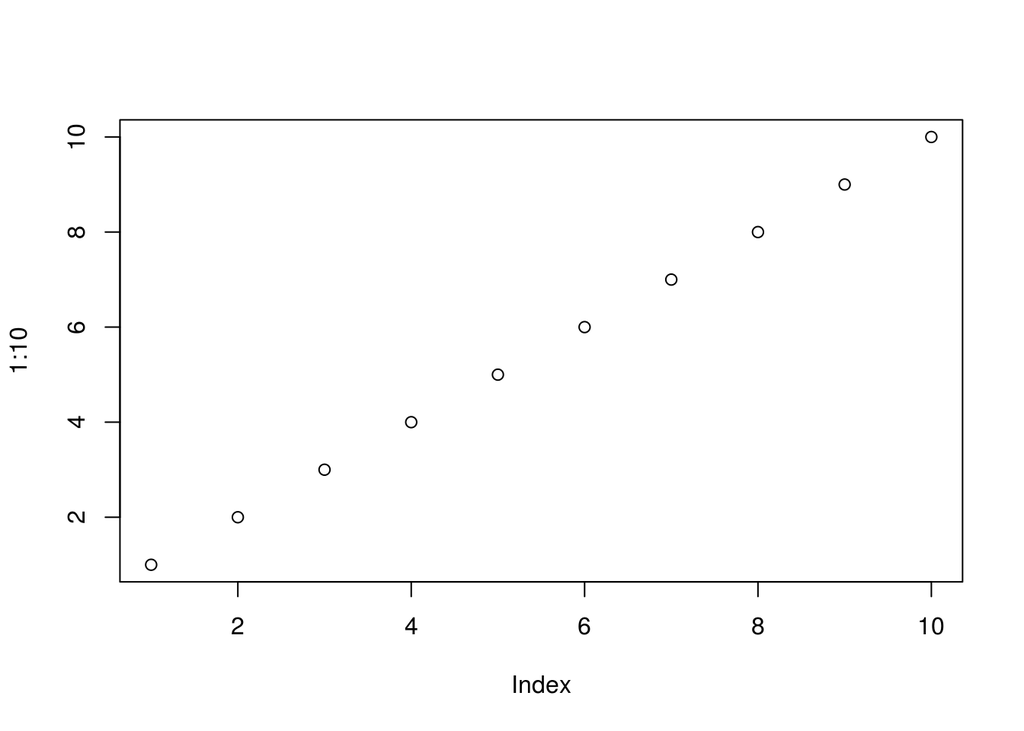

```r
plot(1:10)
```

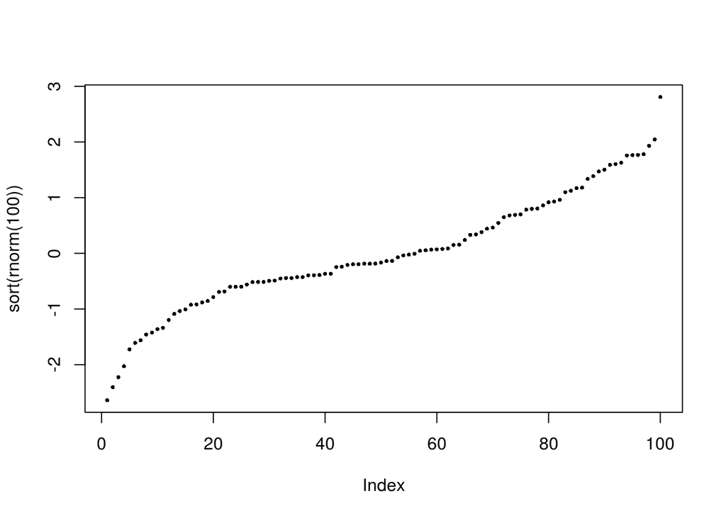

```r
plot(sort(rnorm(100)), pch=16, cex=0.5)                 # specifying point and size respectively
```

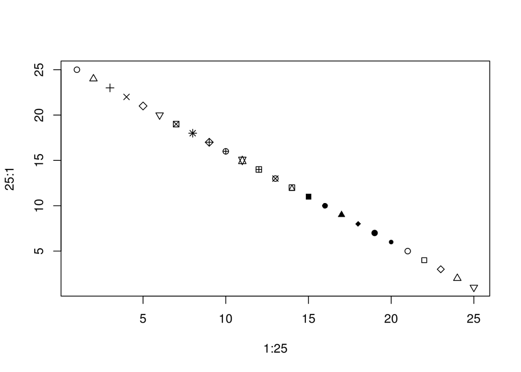

```r
plot(x=1:25, y=25:1, pch=1:25)                          # x & y inputs, and showing the available point symbols
```

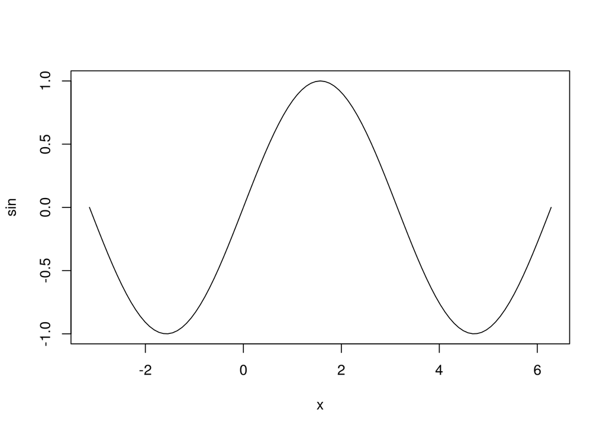

```r
plot(sin, -pi, 2*pi)
```

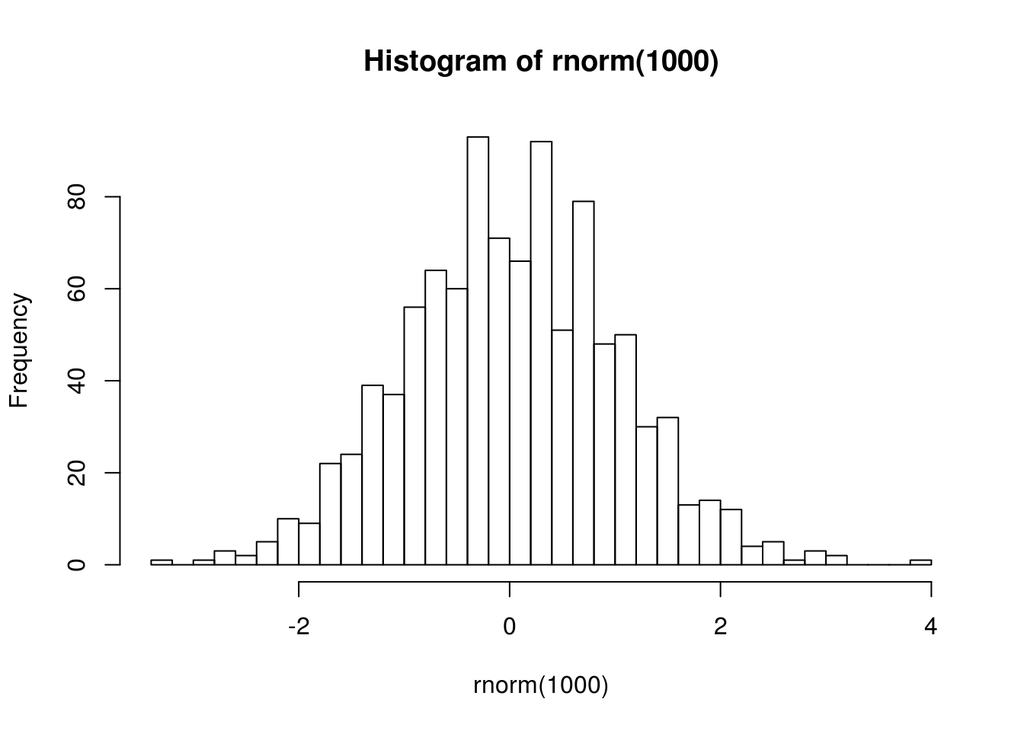

```r
hist(rnorm(1000), breaks=50)
```

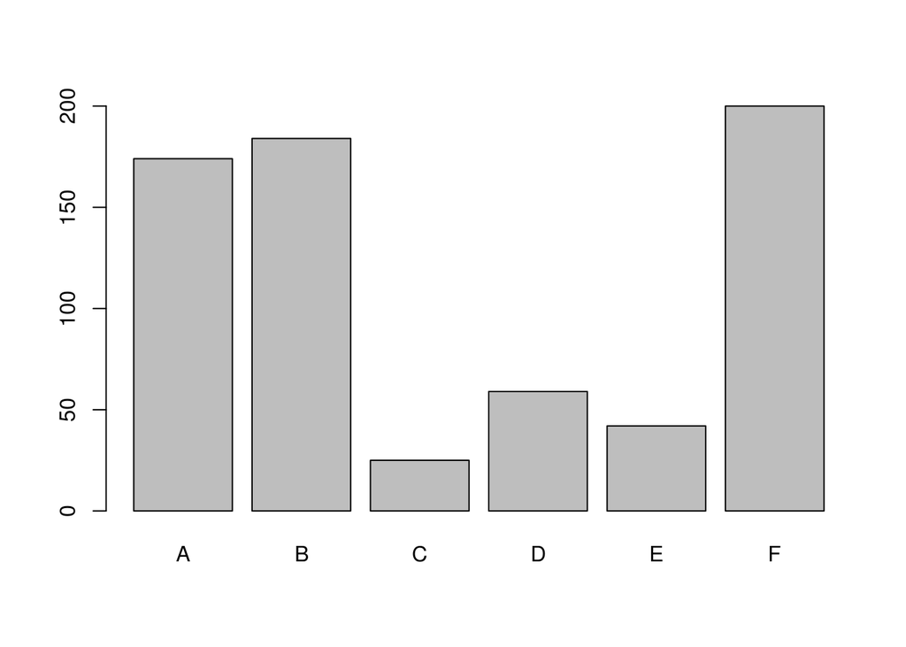

```r
barplot(sumInsects$sum, names.arg = sumInsects$group)
```

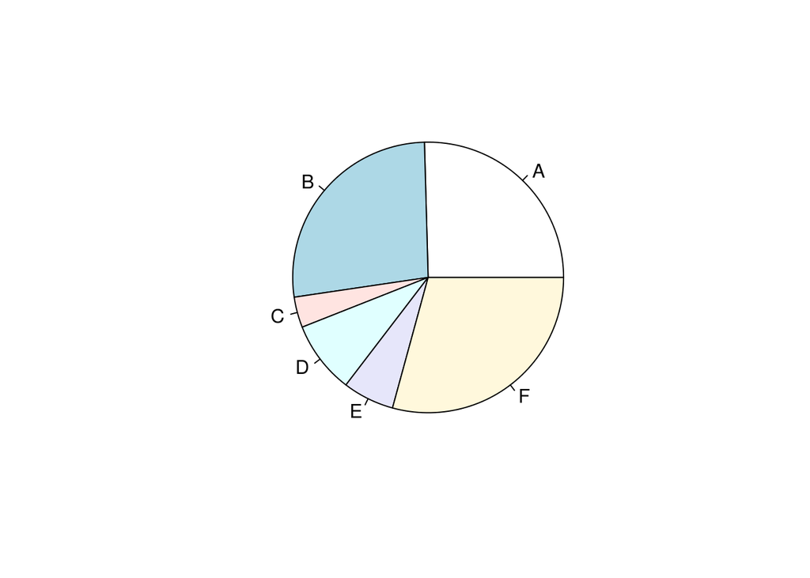

```r
pie(sumInsects$sum, labels = sumInsects$group)
```

plots with more visual components are built up incrementally

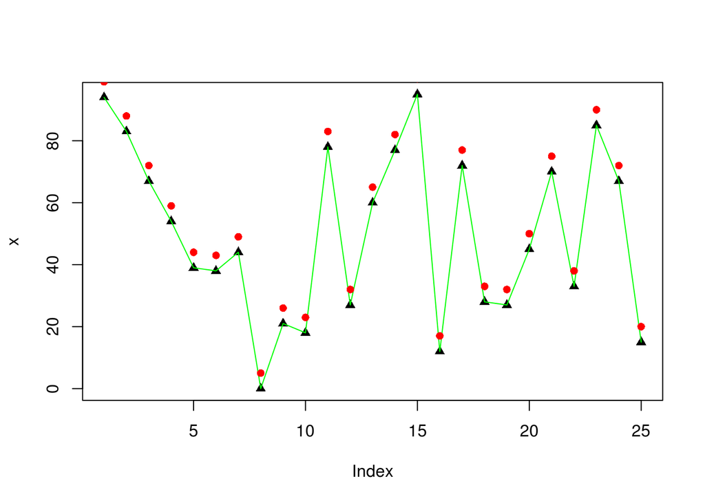

```r
x <- sample(0:100, 25, replace=TRUE)
plot(x, pch=17)
lines(x, col='#00FF00')
points(x+5, pch=16, col='red')
```

stacking charts

```r
warpbreaks
```

```
##    breaks wool tension
## 1      26    A       L
## 2      30    A       L
## 3      54    A       L
## 4      25    A       L
## 5      70    A       L
## 6      52    A       L
## 7      51    A       L
## 8      26    A       L
## 9      67    A       L
## 10     18    A       M
## 11     21    A       M
## 12     29    A       M
## 13     17    A       M
## 14     12    A       M
```

[output cut: 41 more lines]

```r
sumWB <- aggregate(warpbreaks$breaks, by=list(warpbreaks$wool, warpbreaks$tension), FUN=mean)
names(sumWB) <- c('wool','tension','mean_breaks')
sumWB
```

```
##   wool tension mean_breaks
## 1    A       L    44.55556
## 2    B       L    28.22222
## 3    A       M    24.00000
## 4    B       M    30.10000
## 5    A       H    24.55556
## 6    B       H    18.77778
```

```r
(data <- cbind(sumWB$mean_breaks[c(1,3,5)], sumWB$mean_breaks[c(2,4,6)]))
```

```
##          [,1]     [,2]
## [1,] 44.55556 28.22222
## [2,] 24.00000 30.10000
## [3,] 24.55556 18.77778
```

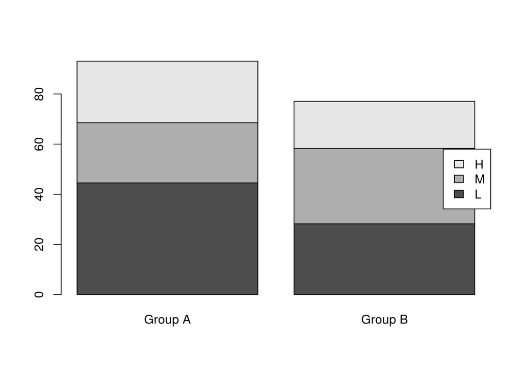

```r
barplot(data, names.arg=c('Group A','Group B'),
        legend.text=c('L','M','H'), args.legend = list(x = "right"))
```

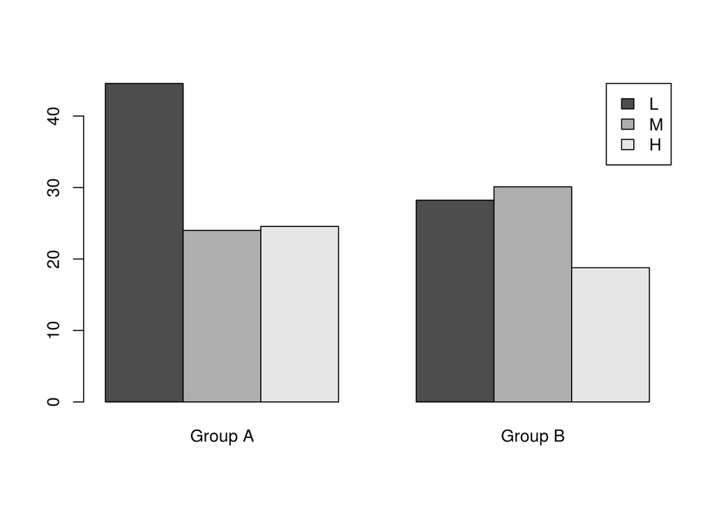

```r
barplot(data, names.arg=c('Group A','Group B'), beside=T,
        legend.text=c('L','M','H'), args.legend = list(x = "topright"))
```

`symbols()` is a good way to represent a 3rd data dimension (use square root for area proportionality)

```r
(cities <- data.frame(city=c('London','Bristol','Manchester','Leeds'),
                      lon=c(-0.1,-2.6,-2.2,-1.5), lat=c(51.5,51.4,53.5,53.8), pop=c(8,1,2.7,0.8)))
```

```
##         city  lon  lat pop
## 1     London -0.1 51.5 8.0
## 2    Bristol -2.6 51.4 1.0
## 3 Manchester -2.2 53.5 2.7
## 4      Leeds -1.5 53.8 0.8
```

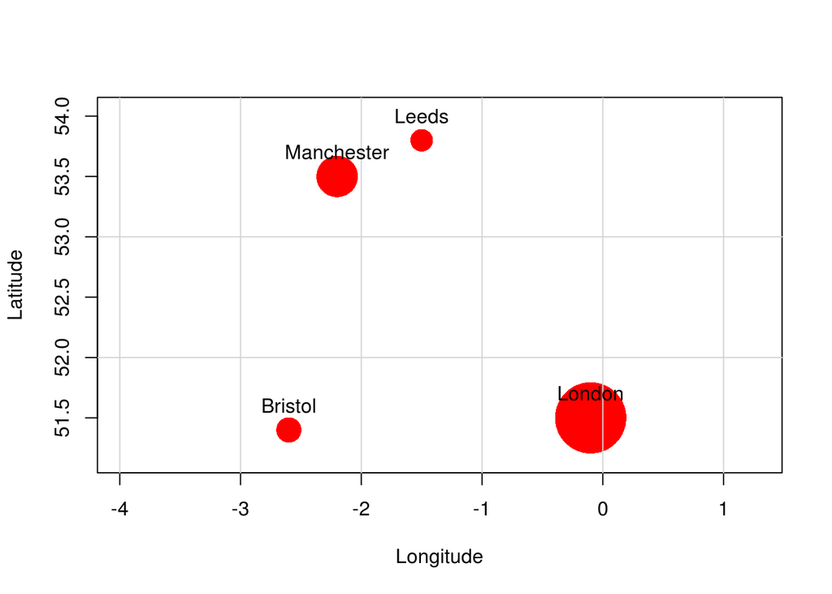

```r
symbols(x=cities$lon, y=cities$lat, circles=sqrt(cities$pop), inches=0.3,
        bg='red', fg=NULL, asp=T, xlab='Longitude', ylab='Latitude')
abline(h=(seq(51,53,1)), col="lightgray", lty=1)
abline(v=(seq(-4,1,1)), col="lightgray", lty=1)
text(x=cities$lon, y=cities$lat+0.2, labels=cities$city)
```

But for much easier and more elegant data visualisation use GGPLOT2

END OF SCRIPT